# Data_Mining_Lab1

```python
#import all the necessary libraries
import numpy as np
import pandas as pd
import matplotlib.pyplot as plt
import seaborn as sns
```

```python
#import the iris.csv file
df=pd.read_csv("iris.csv")
```

```python
#getting the head of the iris dataset (first 5 rows)
df.head()
```

|  | sepal.length | sepal.width | petal.length | petal.width | variety |
| --- | --- | --- | --- | --- | --- |
| 0 | 5.1 | 3.5 | 1.4 | 0.2 | Setosa |
| 1 | 4.9 | 3.0 | 1.4 | 0.2 | Setosa |
| 2 | 4.7 | 3.2 | 1.3 | 0.2 | Setosa |
| 3 | 4.6 | 3.1 | 1.5 | 0.2 | Setosa |
| 4 | 5.0 | 3.6 | 1.4 | 0.2 | Setosa |

```python
#getting the column names of the iris data set
df.columns
```

```
Index(['sepal.length', 'sepal.width', 'petal.length', 'petal.width',
       'variety'],
      dtype='object')
```

```python
#renaming the column names
df.rename(columns={'sepal.length':'sepallength','sepal.width':'sepalwidth','petal.length':'petallength','petal.width':'petalwidth'},inplace=True)
```

# 1. Find Central tendency for each attribute of IRIS data set

```python
#describing the dataset
df.describe()
```

|  | sepallength | sepalwidth | petallength | petalwidth |
| --- | --- | --- | --- | --- |
| count | 150.000000 | 150.000000 | 150.000000 | 150.000000 |
| mean | 5.843333 | 3.057333 | 3.758000 | 1.199333 |
| std | 0.828066 | 0.435866 | 1.765298 | 0.762238 |
| min | 4.300000 | 2.000000 | 1.000000 | 0.100000 |
| 25% | 5.100000 | 2.800000 | 1.600000 | 0.300000 |
| 50% | 5.800000 | 3.000000 | 4.350000 | 1.300000 |
| 75% | 6.400000 | 3.300000 | 5.100000 | 1.800000 |
| max | 7.900000 | 4.400000 | 6.900000 | 2.500000 |

MEAN

```python
print('MEAN OF SEPAL LENGTH: ')
df.sepallength.mean()
```

```
MEAN OF SEPAL LENGTH:
```

```
5.843333333333335
```

```python
print('MEAN OF SEPAL WIDTH: ')
df.sepalwidth.mean()
```

```
MEAN OF SEPAL WIDTH:
```

```
3.057333333333334
```

```python
print('MEAN OF PETAL LENGTH: ')
df.petallength.mean()
```

```
MEAN OF PETAL LENGTH:
```

```
3.7580000000000027
```

```python
print('MEAN OF PETAL WIDTH: ')
df.petalwidth.mean()
```

```
MEAN OF PETAL WIDTH:
```

```
1.199333333333334
```

MEDIAN

```python
print('MEDIAN OF SEPAL LENGTH: ',df.sepallength.median())
print('MEDIAN OF SEPAL WIDTH: ',df.sepalwidth.median())
print('MEDIAN OF PETAL LENGTH: ',df.petallength.median())
print('MEDIAN OF PETAL WIDTH: ',df.petalwidth.median())
```

```
MEDIAN OF SEPAL LENGTH:  5.8
MEDIAN OF SEPAL WIDTH:  3.0
MEDIAN OF PETAL LENGTH:  4.35
MEDIAN OF PETAL WIDTH:  1.3
```

MODE

```python
print('MODE OF SEPAL LENGTH: ',df.sepallength.mode())
print('MODE OF SEPAL WIDTH: ',df.sepalwidth.mode())
print('MODE OF PETAL LENGTH: ',df.petallength.mode())
print('MODE OF PETAL WIDTH: ',df.petalwidth.mode())
```

```
MODE OF SEPAL LENGTH:  0    5.0
dtype: float64
MODE OF SEPAL WIDTH:  0    3.0
dtype: float64
MODE OF PETAL LENGTH:  0    1.4
1    1.5
dtype: float64
MODE OF PETAL WIDTH:  0    0.2
dtype: float64
```

# 2. Compare different means for all attributes

THE BOXPLOTS OF SEPAL LENGTH, SEPAL WIDTH, PETAL LENGTH, PETAL WIDTH

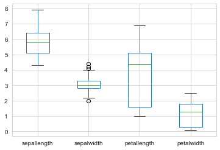

```python
df.boxplot()
```

DIVIDING THE DATASET INTO THREE PARTS WITH RESPECT TO THE VARIETY

The respective dataframes are iris_setosa, iris_virginica,iris_versicolor

```python
iris_setosa=df.loc[df["variety"]=="Setosa"]
iris_virginica=df.loc[df["variety"]=="Virginica"]
iris_versicolor=df.loc[df["variety"]=="Versicolor"]
```

INFORAMATION ON IRIS-SETOSA

```python
iris_setosa.describe()
```

|  | sepallength | sepalwidth | petallength | petalwidth |
| --- | --- | --- | --- | --- |
| count | 50.00000 | 50.000000 | 50.000000 | 50.000000 |
| mean | 5.00600 | 3.428000 | 1.462000 | 0.246000 |
| std | 0.35249 | 0.379064 | 0.173664 | 0.105386 |
| min | 4.30000 | 2.300000 | 1.000000 | 0.100000 |
| 25% | 4.80000 | 3.200000 | 1.400000 | 0.200000 |
| 50% | 5.00000 | 3.400000 | 1.500000 | 0.200000 |
| 75% | 5.20000 | 3.675000 | 1.575000 | 0.300000 |
| max | 5.80000 | 4.400000 | 1.900000 | 0.600000 |

INFORAMATION ON IRIS-VIRGINICA

```python
iris_virginica.describe()
```

|  | sepallength | sepalwidth | petallength | petalwidth |
| --- | --- | --- | --- | --- |
| count | 50.00000 | 50.000000 | 50.000000 | 50.00000 |
| mean | 6.58800 | 2.974000 | 5.552000 | 2.02600 |
| std | 0.63588 | 0.322497 | 0.551895 | 0.27465 |
| min | 4.90000 | 2.200000 | 4.500000 | 1.40000 |
| 25% | 6.22500 | 2.800000 | 5.100000 | 1.80000 |
| 50% | 6.50000 | 3.000000 | 5.550000 | 2.00000 |
| 75% | 6.90000 | 3.175000 | 5.875000 | 2.30000 |
| max | 7.90000 | 3.800000 | 6.900000 | 2.50000 |

INFORAMATION ON IRIS-VERSICOLOR

```python
iris_versicolor.describe()
```

|  | sepallength | sepalwidth | petallength | petalwidth |
| --- | --- | --- | --- | --- |
| count | 50.000000 | 50.000000 | 50.000000 | 50.000000 |
| mean | 5.936000 | 2.770000 | 4.260000 | 1.326000 |
| std | 0.516171 | 0.313798 | 0.469911 | 0.197753 |
| min | 4.900000 | 2.000000 | 3.000000 | 1.000000 |
| 25% | 5.600000 | 2.525000 | 4.000000 | 1.200000 |
| 50% | 5.900000 | 2.800000 | 4.350000 | 1.300000 |
| 75% | 6.300000 | 3.000000 | 4.600000 | 1.500000 |
| max | 7.000000 | 3.400000 | 5.100000 | 1.800000 |

# 3. Compare mean and median for each attribute and comment on the distribution of data

```python
print("no of samples available for each type")
print(df["variety"].value_counts())
print("*********")
```

```
no of samples available for each type
Virginica     50
Versicolor    50
Setosa        50
Name: variety, dtype: int64
*********
```

THE BOX PLOT OF IRIS_SETOSA

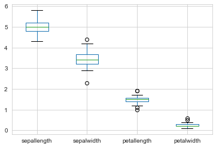

```python
iris_setosa.boxplot()
```

THE BOX PLOT OF IRIS_VIRGINICA

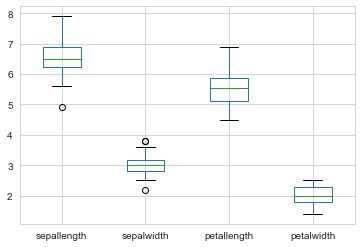

```python
iris_virginica.boxplot()
```

THE BOX PLOT OF IRIS_VERSICOLOR

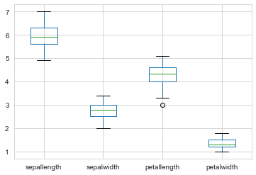

```python
iris_versicolor.boxplot()
```

COMPARING THE MEANS AND MEDIANS OF IRIS SETOSA ATTRIBUTES

```python
mean=iris_setosa.sepallength.mean()
median=iris_setosa.sepallength.median()
```

```python
print("MEAN OF IRIS SETOSA SEPAL LENGTH: ",mean)
print("MEDIAN OF IRIS SETOSA SEPAL LENGTH: ",median)
```

```
MEAN OF IRIS SETOSA SEPAL LENGTH:  5.005999999999999
MEDIAN OF IRIS SETOSA SEPAL LENGTH:  5.0
```

```python
mean=iris_setosa.sepalwidth.mean()
median=iris_setosa.sepalwidth.median()
```

```python
print("MEAN OF IRIS SETOSA SEPAL WIDTH: ",mean)
print("MEDIAN OF IRIS SETOSA SEPAL WIDTH: ",median)
```

```
MEAN OF IRIS SETOSA SEPAL WIDTH:  3.428000000000001
MEDIAN OF IRIS SETOSA SEPAL WIDTH:  3.4
```

```python
mean=iris_setosa.petallength.mean()
median=iris_setosa.petallength.median()
```

```python
print("MEAN OF IRIS SETOSA PETAL LENGTH: ",mean)
print("MEDIAN OF IRIS SETOSA PETAL LENGTH: ",median)
```

```
MEAN OF IRIS SETOSA PETAL LENGTH:  1.4620000000000002
MEDIAN OF IRIS SETOSA PETAL LENGTH:  1.5
```

```python
mean=iris_setosa.petalwidth.mean()
median=iris_setosa.petalwidth.median()
```

```python
print("MEAN OF IRIS SETOSA PETAL WIDTH: ",mean)
print("MEDIAN OF IRIS SETOSA PETAL WIDTH: ",median)
```

```
MEAN OF IRIS SETOSA PETAL WIDTH:  0.2459999999999999
MEDIAN OF IRIS SETOSA PETAL WIDTH:  0.2
```

COMPARING THE MEANS AND MEDIANS OF IRIS VIRGINICA ATTRIBUTES

```python
mean=iris_virginica.sepallength.mean()
median=iris_virginica.sepallength.median()
print("MEAN OF IRIS virginica SEPAL LENGTH: ",mean)
print("MEDIAN OF IRIS virginica SEPAL LENGTH: ",median)
mean=iris_virginica.sepalwidth.mean()
median=iris_virginica.sepalwidth.median()
print("MEAN OF IRIS virginica SEPAL WIDTH: ",mean)
print("MEDIAN OF IRIS virginica SEPAL WIDTH: ",median)
mean=iris_virginica.petallength.mean()
median=iris_virginica.petallength.median()
print("MEAN OF IRIS virginica PETAL LENGTH: ",mean)
print("MEDIAN OF IRIS virginica PETAL LENGTH: ",median)
mean=iris_virginica.petalwidth.mean()
median=iris_virginica.petalwidth.median()
print("MEAN OF IRIS virginica PETAL WIDTH: ",mean)
print("MEDIAN OF IRIS virginica PETAL WIDTH: ",median)
```

```
MEAN OF IRIS virginica SEPAL LENGTH:  6.587999999999998
MEDIAN OF IRIS virginica SEPAL LENGTH:  6.5
MEAN OF IRIS virginica SEPAL WIDTH:  2.9739999999999998
MEDIAN OF IRIS virginica SEPAL WIDTH:  3.0
MEAN OF IRIS virginica PETAL LENGTH:  5.552
MEDIAN OF IRIS virginica PETAL LENGTH:  5.55
MEAN OF IRIS virginica PETAL WIDTH:  2.026
MEDIAN OF IRIS virginica PETAL WIDTH:  2.0
```

COMPARING THE MEANS AND MEDIANS OF IRIS VERSICOLOR ATTRIBUTES

```python
mean=iris_versicolor.sepallength.mean()
median=iris_versicolor.sepallength.median()
print("MEAN OF IRIS versicolor SEPAL LENGTH: ",mean)
print("MEDIAN OF IRIS versicolor SEPAL LENGTH: ",median)
mean=iris_versicolor.sepalwidth.mean()
median=iris_versicolor.sepalwidth.median()
print("MEAN OF IRIS versicolor SEPAL WIDTH: ",mean)
print("MEDIAN OF IRIS versicolor SEPAL WIDTH: ",median)
mean=iris_versicolor.petallength.mean()
median=iris_versicolor.petallength.median()
print("MEAN OF IRIS versicolor PETAL LENGTH: ",mean)
print("MEDIAN OF IRIS versicolor PETAL LENGTH: ",median)
mean=iris_versicolor.petalwidth.mean()
median=iris_versicolor.petalwidth.median()
print("MEAN OF IRIS versicolor PETAL WIDTH: ",mean)
print("MEDIAN OF IRIS versicolor PETAL WIDTH: ",median)
```

[output not shown]

[output not shown]

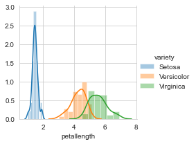

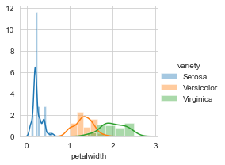

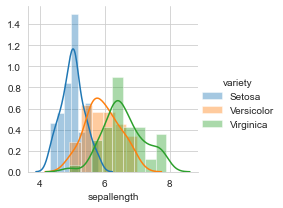

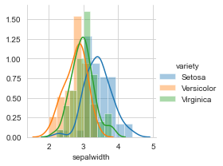

```python
sns.FacetGrid(df,hue="variety",size=3).map(sns.distplot,"petallength").add_legend()
sns.FacetGrid(df,hue="variety",size=3).map(sns.distplot,"petalwidth").add_legend()
sns.FacetGrid(df,hue="variety",size=3).map(sns.distplot,"sepallength").add_legend()
sns.FacetGrid(df,hue="variety",size=3).map(sns.distplot,"sepalwidth").add_legend()
```

# 4. Compute 5-number summary and represent with boxplots for each attribute

The five number summary includes 5 items:

The minimum. Q1 (the first quartile, or the 25% mark). The median. Q3 (the third quartile, or the 75% mark). The maximum.

5-number summary for sepal length

```python
# print 5-number summary
data_min=df.sepallength.min()
data_max=df.sepallength.max()
quartiles = np.percentile(df.sepallength, [25, 50, 75])
print('Min: %.3f' % data_min)
print('Q1: %.3f' % quartiles[0])
print('Median: %.3f' % quartiles[1])
print('Q3: %.3f' % quartiles[2])
print('Max: %.3f' % data_max)
```

```
Min: 4.300
Q1: 5.100
Median: 5.800
Q3: 6.400
Max: 7.900
```

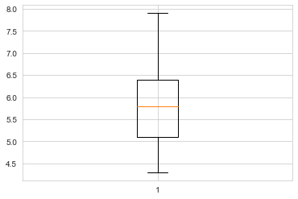

```python
plt.boxplot(df.sepallength)
plt.show()
```

5-number summary for sepal width

```python
# print 5-number summary
data_min=df.sepalwidth.min()
data_max=df.sepalwidth.max()
quartiles = np.percentile(df.sepalwidth, [25, 50, 75])
print('Min: %.3f' % data_min)
print('Q1: %.3f' % quartiles[0])
print('Median: %.3f' % quartiles[1])
print('Q3: %.3f' % quartiles[2])
print('Max: %.3f' % data_max)
```

```
Min: 2.000
Q1: 2.800
Median: 3.000
Q3: 3.300
Max: 4.400
```

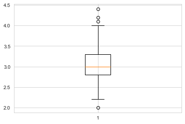

```python
plt.boxplot(df.sepalwidth)
plt.show()
```

5-number summary for petal length

```python
# print 5-number summary
data_min=df.petallength.min()
data_max=df.petallength.max()
quartiles = np.percentile(df.petallength, [25, 50, 75])
print('Min: %.3f' % data_min)
print('Q1: %.3f' % quartiles[0])
print('Median: %.3f' % quartiles[1])
print('Q3: %.3f' % quartiles[2])
print('Max: %.3f' % data_max)
```

```
Min: 1.000
Q1: 1.600
Median: 4.350
Q3: 5.100
Max: 6.900
```

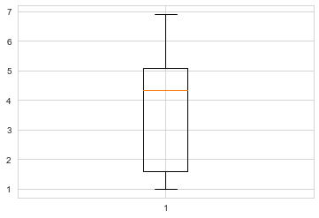

```python
plt.boxplot(df.petallength)
plt.show()
```

5-number summary for petal width

```python
# print 5-number summary
data_min=df.petalwidth.min()
data_max=df.petalwidth.max()
quartiles = np.percentile(df.petalwidth, [25, 50, 75])
print('Min: %.3f' % data_min)
print('Q1: %.3f' % quartiles[0])
print('Median: %.3f' % quartiles[1])
print('Q3: %.3f' % quartiles[2])
print('Max: %.3f' % data_max)
```

```
Min: 0.100
Q1: 0.300
Median: 1.300
Q3: 1.800
Max: 2.500
```

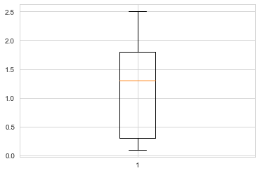

```python
plt.boxplot(df.petalwidth)
plt.show()
```

# 5. Compute variance and standard deviation for each attribute and comment on the spread of data

```python
import statistics
```

The Python statistics module also provides functions to calculate the standard deviation. We can find pstdev() and stdev(). The first function takes the data of an entire population and returns its standard deviation. The second function takes data from a sample and returns an estimation of the population standard deviation.

```python
print("THE VARIANCE OF SEPAL LENGTH: ",statistics.pstdev(df.sepallength)*statistics.pstdev(df.sepallength),"THE STANDARD DEVAITION OF SEPAL LENGTH: ",statistics.pstdev(df.sepallength))
print("THE VARIANCE OF SEPAL WIDTH: ",statistics.pstdev(df.sepalwidth)*statistics.pstdev(df.sepalwidth),"THE STANDARD DEVAITION OF SEPAL WIDTH: ",statistics.pstdev(df.sepalwidth))
print("THE VARIANCE OF PETAL LENGTH: ",statistics.pstdev(df.petallength)*statistics.pstdev(df.petallength),"THE STANDARD DEVAITION OF PETAL LENGTH: ",statistics.pstdev(df.petallength))
print("THE VARIANCE OF PETAL WIDTH: ",statistics.pstdev(df.petalwidth)*statistics.pstdev(df.petalwidth),"THE STANDARD DEVAITION OF PETAL WIDTH: ",statistics.pstdev(df.petalwidth))
```

```
THE VARIANCE OF SEPAL LENGTH:  0.6811222222222223 THE STANDARD DEVAITION OF SEPAL LENGTH:  0.8253012917851409
THE VARIANCE OF SEPAL WIDTH:  0.18871288888888887 THE STANDARD DEVAITION OF SEPAL WIDTH:  0.43441096773549454
THE VARIANCE OF PETAL LENGTH:  3.0955026666666665 THE STANDARD DEVAITION OF PETAL LENGTH:  1.759404065775303
THE VARIANCE OF PETAL WIDTH:  0.5771328888888888 THE STANDARD DEVAITION OF PETAL WIDTH:  0.7596926279021594
```

[output not shown]

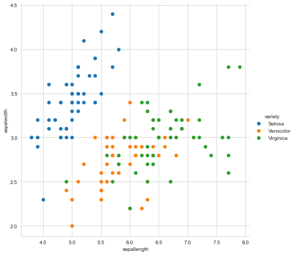

```python
sns.set_style("whitegrid");
sns.FacetGrid(df,hue="variety",size=7) \
   .map(plt.scatter, "sepallength","sepalwidth") \
   .add_legend();
plt.show()
```

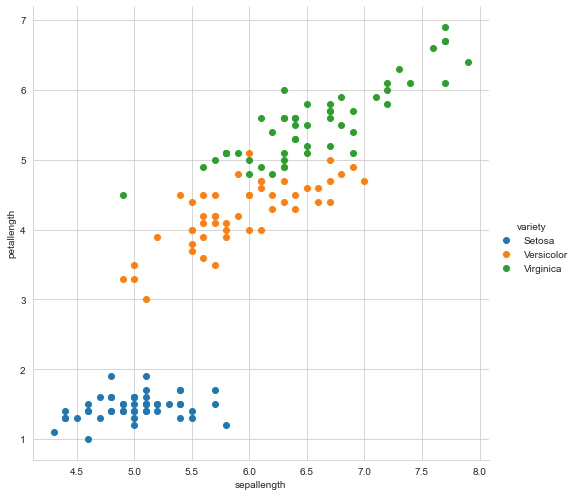

```python
sns.set_style("whitegrid");
sns.FacetGrid(df,hue="variety",size=7) \
   .map(plt.scatter, "sepallength","petallength") \
   .add_legend();
plt.show()
```

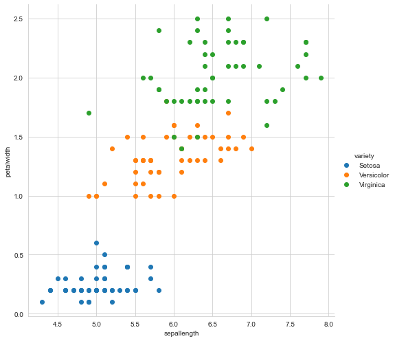

```python
sns.set_style("whitegrid");
sns.FacetGrid(df,hue="variety",size=7) \
   .map(plt.scatter, "sepallength","petalwidth") \
   .add_legend();
plt.show()
```

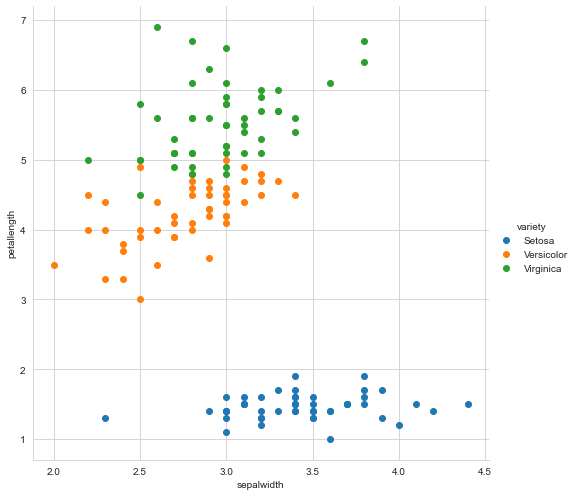

```python
sns.set_style("whitegrid");
sns.FacetGrid(df,hue="variety",size=7).map(plt.scatter, "sepalwidth","petallength").add_legend();
plt.show()
```

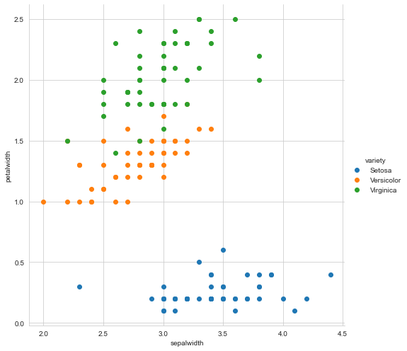

```python
sns.set_style("whitegrid");
sns.FacetGrid(df,hue="variety",size=7) \
   .map(plt.scatter, "sepalwidth","petalwidth") \
   .add_legend();
plt.show()
```

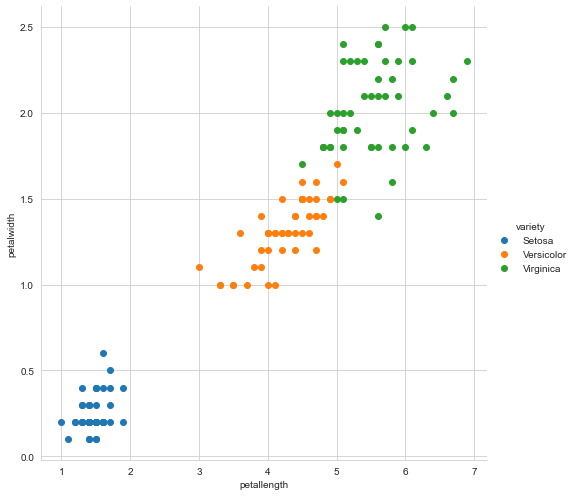

```python
sns.set_style("whitegrid");
sns.FacetGrid(df,hue="variety",size=7) \
   .map(plt.scatter, "petallength","petalwidth") \
   .add_legend();
plt.show()
```

THE SPREAD OF DATA USING HISTOGRAMS FOR SEPAL LENGTH

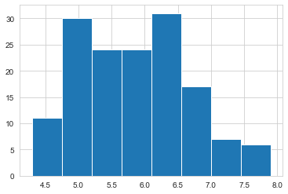

```python
df['sepallength'].hist(bins=8)
```

THE SPREAD OF DATA USING HISTOGRAMS FOR SEPAL WIDTH

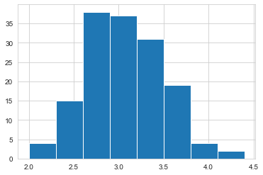

```python
df['sepalwidth'].hist(bins=8)
```

THE SPREAD OF DATA USING HISTOGRAMS FOR PETAL LENGTH

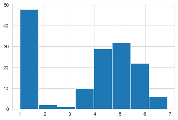

```python
df['petallength'].hist(bins=8)
```

THE SPREAD OF DATA USING HISTOGRAMS FOR PETAL WIDTH

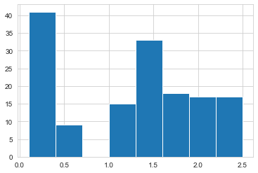

```python
df['petalwidth'].hist(bins=8)
```

```python
print("no of samples available for each type")
print(df["variety"].value_counts())
print("*********")
```

```
no of samples available for each type
Virginica     50
Versicolor    50
Setosa        50
Name: variety, dtype: int64
*********
```

# 6. Find correlation coefficient for each pair of attributes in IRIS data set

```python
print("FINDING CO RELATION COEFFICIENT FOR IRIS DATASET")
```

```
FINDING CO RELATION COEFFICIENT FOR IRIS DATASET
```

```python
df.corr()
```

|  | sepallength | sepalwidth | petallength | petalwidth |
| --- | --- | --- | --- | --- |
| sepallength | 1.000000 | -0.117570 | 0.871754 | 0.817941 |
| sepalwidth | -0.117570 | 1.000000 | -0.428440 | -0.366126 |
| petallength | 0.871754 | -0.428440 | 1.000000 | 0.962865 |
| petalwidth | 0.817941 | -0.366126 | 0.962865 | 1.000000 |

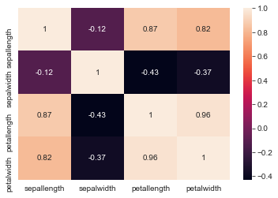

```python
sns.heatmap(df.corr(),annot=True)
```

```python
print("FINDING CO RELATION COEFFICIENT FOR IRIS-setosa DATAFRAME")
```

```
FINDING CO RELATION COEFFICIENT FOR IRIS-setosa DATAFRAME
```

```python
iris_setosa.corr()
```

|  | sepallength | sepalwidth | petallength | petalwidth |
| --- | --- | --- | --- | --- |
| sepallength | 1.000000 | 0.742547 | 0.267176 | 0.278098 |
| sepalwidth | 0.742547 | 1.000000 | 0.177700 | 0.232752 |
| petallength | 0.267176 | 0.177700 | 1.000000 | 0.331630 |
| petalwidth | 0.278098 | 0.232752 | 0.331630 | 1.000000 |

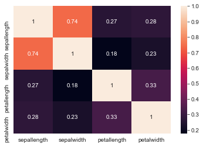

```python
sns.heatmap(iris_setosa.corr(),annot=True)
```

FINDING THE CO RELATION OF IRIS VIRGINICA DATAFRAME

```python
iris_virginica.corr()
```

|  | sepallength | sepalwidth | petallength | petalwidth |
| --- | --- | --- | --- | --- |
| sepallength | 1.000000 | 0.457228 | 0.864225 | 0.281108 |
| sepalwidth | 0.457228 | 1.000000 | 0.401045 | 0.537728 |
| petallength | 0.864225 | 0.401045 | 1.000000 | 0.322108 |
| petalwidth | 0.281108 | 0.537728 | 0.322108 | 1.000000 |

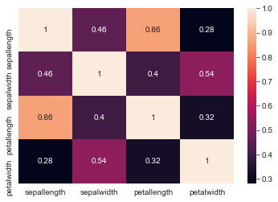

```python
sns.heatmap(iris_virginica.corr(),annot=True)
```

FINDING THE CO RELATION OF IRIS VERSILCOLOR DATAFRAME

```python
iris_versicolor.corr()
```

|  | sepallength | sepalwidth | petallength | petalwidth |
| --- | --- | --- | --- | --- |
| sepallength | 1.000000 | 0.525911 | 0.754049 | 0.546461 |
| sepalwidth | 0.525911 | 1.000000 | 0.560522 | 0.663999 |
| petallength | 0.754049 | 0.560522 | 1.000000 | 0.786668 |
| petalwidth | 0.546461 | 0.663999 | 0.786668 | 1.000000 |

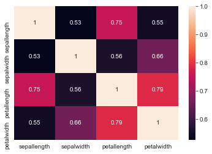

```python
sns.heatmap(iris_versicolor.corr(),annot=True)
```